# Project: Investigate TMDb Dataset

- Introduction
- Data Wrangling
- Exploratory Data Analysis
- Conclusions

## Introduction

In this project, I'll explore the TMDb dataset which contains data releted to movies. Each movie in this dataset has data related to ratings, budget, genre, cast and many other details.

In the first part of the exploration, I'll try to investigate the relationship between genre and other properties like revenue, popolarity, runtime, budget etc. I'll try to find out how revenue, budget, popularity, runtime etc varies according to the genre of the movie. This will be single variable (1d) explorations where genre will be the independent variables and I'll try to find trends in other properties when we vary genre. Then, I'll investigate, the popularity value of a movie over genre and release year (2d exploration) hoping to find interesting trends in the popularity value over the years for each genre. In all these explorations I'll average the value of interest over the genres. e.g., the average value of revenue for each genre. In my opinion the average seems to give a better estimate than the sum or other aggregate functions because the number of movies in a particular genre may be very high and calculating the sum would make it way bigger than other genres, thus leading to wrong interpretations.

In the second part of the exploration, I'll investigate the properties of a high revenue movie, specifically, how the revenue varies with other properties like average vote, number of votes, popularity etc. I'll also investigate how the average revenue varies over the years and if there is any relationship between average rating, average vote count, average popularity and revenue over the years.

At the end, I'll do some analysis of runtime and average rating.

```python
# import statements for packages needed
import numpy as np
import pandas as pd
import matplotlib.pyplot as plt
from datetime import datetime as dt

# magic word to plot visualizations in the notebook itself
%matplotlib inline
```

## Data Wrangling

Loaded the data from the csv file using pandas. Examined the first few rows. The data loaded correctly.

### General Properties

> No of rows: 10866, No of columns: 21

Each row contains data related to a single movie. Each movie has a popularity index, rating information, budget and revenue information, a set of genres the movie belong to, runtime, relese year and release date. Then there are other properties like the original title, cast, homepage, director, tagline, overview. It also has budget and revenue information based on 2010 dollar values which may be of help when we want to remove the effect of inflation over the years.

Some sample data points are shown below along with all the column values.

```python
# load data from csv and find out basic info
df = pd.read_csv('./tmdb-movies.csv')
print(df.shape)
df.head()
```

```
(10866, 21)
```

|  | id | imdb_id | popularity | budget | revenue | original_title | cast | homepage | director | tagline | ... | overview | runtime | genres | production_companies | release_date | vote_count | vote_average | release_year | budget_adj | revenue_adj |
| --- | --- | --- | --- | --- | --- | --- | --- | --- | --- | --- | --- | --- | --- | --- | --- | --- | --- | --- | --- | --- | --- |
| 0 | 135397 | tt0369610 | 32.985763 | 150000000 | 1513528810 | Jurassic World | Chris Pratt\|Bryce Dallas Howard\|Irrfan Khan\|Vi... | http://www.jurassicworld.com/ | Colin Trevorrow | The park is open. | ... | Twenty-two years after the events of Jurassic ... | 124 | Action\|Adventure\|Science Fiction\|Thriller | Universal Studios\|Amblin Entertainment\|Legenda... | 6/9/15 | 5562 | 6.5 | 2015 | 1.379999e+08 | 1.392446e+09 |
| 1 | 76341 | tt1392190 | 28.419936 | 150000000 | 378436354 | Mad Max: Fury Road | Tom Hardy\|Charlize Theron\|Hugh Keays-Byrne\|Nic... | http://www.madmaxmovie.com/ | George Miller | What a Lovely Day. | ... | An apocalyptic story set in the furthest reach... | 120 | Action\|Adventure\|Science Fiction\|Thriller | Village Roadshow Pictures\|Kennedy Miller Produ... | 5/13/15 | 6185 | 7.1 | 2015 | 1.379999e+08 | 3.481613e+08 |
| 2 | 262500 | tt2908446 | 13.112507 | 110000000 | 295238201 | Insurgent | Shailene Woodley\|Theo James\|Kate Winslet\|Ansel... | http://www.thedivergentseries.movie/#insurgent | Robert Schwentke | One Choice Can Destroy You | ... | Beatrice Prior must confront her inner demons ... | 119 | Adventure\|Science Fiction\|Thriller | Summit Entertainment\|Mandeville Films\|Red Wago... | 3/18/15 | 2480 | 6.3 | 2015 | 1.012000e+08 | 2.716190e+08 |
| 3 | 140607 | tt2488496 | 11.173104 | 200000000 | 2068178225 | Star Wars: The Force Awakens | Harrison Ford\|Mark Hamill\|Carrie Fisher\|Adam D... | http://www.starwars.com/films/star-wars-episod... | J.J. Abrams | Every generation has a story. | ... | Thirty years after defeating the Galactic Empi... | 136 | Action\|Adventure\|Science Fiction\|Fantasy | Lucasfilm\|Truenorth Productions\|Bad Robot | 12/15/15 | 5292 | 7.5 | 2015 | 1.839999e+08 | 1.902723e+09 |
| 4 | 168259 | tt2820852 | 9.335014 | 190000000 | 1506249360 | Furious 7 | Vin Diesel\|Paul Walker\|Jason Statham\|Michelle ... | http://www.furious7.com/ | James Wan | Vengeance Hits Home | ... | Deckard Shaw seeks revenge against Dominic Tor... | 137 | Action\|Crime\|Thriller | Universal Pictures\|Original Film\|Media Rights ... | 4/1/15 | 2947 | 7.3 | 2015 | 1.747999e+08 | 1.385749e+09 |

5 rows × 21 columns

```python
# investigate each column
df.info()
```

```
<class 'pandas.core.frame.DataFrame'>
RangeIndex: 10866 entries, 0 to 10865
Data columns (total 21 columns):
id                      10866 non-null int64
imdb_id                 10856 non-null object
popularity              10866 non-null float64
budget                  10866 non-null int64
revenue                 10866 non-null int64
original_title          10866 non-null object
cast                    10790 non-null object
homepage                2936 non-null object
director                10822 non-null object
tagline                 8042 non-null object
keywords                9373 non-null object
overview                10862 non-null object
runtime                 10866 non-null int64
genres                  10843 non-null object
production_companies    9836 non-null object
release_date            10866 non-null object
vote_count              10866 non-null int64
vote_average            10866 non-null float64
release_year            10866 non-null int64
budget_adj              10866 non-null float64
revenue_adj             10866 non-null float64
dtypes: float64(4), int64(6), object(11)
memory usage: 1.7+ MB
```

### Data Cleaning

As shown above, there are a lot of null values in the columns. In the next few cells I'll perform some data cleaning steps to make the data useful for our future explorations. Please find the comments after each step. First I'll find out if there is any duplicate row in the dataset.

```python
# remove any duplicate row if exists
print(df.duplicated().sum())
df.drop_duplicates(inplace=True)
```

```
1
```

Found out that there is a duplicate row in the dataset. Removed it. Now, I'll examine null values.

```python
# check for null values
df.isnull().sum()
```

```
id                         0
imdb_id                   10
popularity                 0
budget                     0
revenue                    0
original_title             0
cast                      76
homepage                7929
director                  44
tagline                 2824
keywords                1493
overview                   4
runtime                    0
genres                    23
production_companies    1030
release_date               0
vote_count                 0
vote_average               0
release_year               0
budget_adj                 0
revenue_adj                0
dtype: int64
```

As examined above, a lot of null values are present in the dataset. A few rows have missing imdb_id and I plan to use imdb_id to uniquely idetify a row. So, I decided to remove those. I'll also remove rows which don't have any genre information as I plan to do data analysis based on genre. I'll not remove/process other columns which have null values as they will not be relevant for my analysis. All columns relevant to my analysis won't have null values after these steps.

```python
# drop rows which have null values in imdb_id and genres column
df.dropna(subset=['imdb_id'], inplace=True)
df.dropna(subset=['genres'], inplace=True)
df.info()
```

```
<class 'pandas.core.frame.DataFrame'>
Int64Index: 10834 entries, 0 to 10865
Data columns (total 21 columns):
id                      10834 non-null int64
imdb_id                 10834 non-null object
popularity              10834 non-null float64
budget                  10834 non-null int64
revenue                 10834 non-null int64
original_title          10834 non-null object
cast                    10759 non-null object
homepage                2929 non-null object
director                10795 non-null object
tagline                 8033 non-null object
keywords                9363 non-null object
overview                10832 non-null object
runtime                 10834 non-null int64
genres                  10834 non-null object
production_companies    9822 non-null object
release_date            10834 non-null object
vote_count              10834 non-null int64
vote_average            10834 non-null float64
release_year            10834 non-null int64
budget_adj              10834 non-null float64
revenue_adj             10834 non-null float64
dtypes: float64(4), int64(6), object(11)
memory usage: 1.8+ MB
```

As shown above, now the dataset doesn't have null values in the fields of inerest. The next step will check if all the rows contain unique movies.

```python
# check identifier columns have any column has duplicated values
print(len(df['id'].unique()))
print(len(df['imdb_id'].unique()))
```

```
10834
10834
```

As seen in the result of the first cell, the genre column of the data frame is a list of concatenated strings which means one movie can belong to multiple genres. First, I'll find out full list of the genres for all the movies

```python
# function to find out the full list of genres
def full_list_of_genres(genres):
    '''
    This function takes the genres column of the dataframe and
    returns the full list of genres of all the movies in dataset
    '''
    genres_str = genres.values.tolist()
    genre_list = []
    for i in genres_str:
        split_genres = i.split('|')
        for j in split_genres:
            if j not in genre_list:
                genre_list.append(j)
    return genre_list

# Get the full list of genres
genres = full_list_of_genres(df['genres'])
```

Now, I'll create a new dataframe which will have all the genre information against a particular movie. I'll go through the whole list of movies and find out the genres and put a 1 in the columns corresponding to the genre the movie belongs to. Then I'll merge the genre dataframe with the original dataframe on imdb_id and create a new dataframe which have the consolidated information.

```python
# create a dataframe with genre info which can be indexed by imdb_id
genre_df = pd.DataFrame(index=range(len(df)) ,columns=genres)
genre_df = genre_df.fillna(value=0)

# fill up the genre df with genre info of each movie
for i in range(len(df)):
    genre_list = df.iloc[i]['genres'].split('|')
    genre_df.loc[i, 'imdb_id'] = df.iloc[i]['imdb_id']
    for j in genre_list:
        genre_df.loc[i, j] = 1

genre_df.head()
```

|  | Action | Adventure | Science Fiction | Thriller | Fantasy | Crime | Western | Drama | Family | Animation | ... | Mystery | Romance | War | History | Music | Horror | Documentary | TV Movie | Foreign | imdb_id |
| --- | --- | --- | --- | --- | --- | --- | --- | --- | --- | --- | --- | --- | --- | --- | --- | --- | --- | --- | --- | --- | --- |
| 0 | 1 | 1 | 1 | 1 | 0 | 0 | 0 | 0 | 0 | 0 | ... | 0 | 0 | 0 | 0 | 0 | 0 | 0 | 0 | 0 | tt0369610 |
| 1 | 1 | 1 | 1 | 1 | 0 | 0 | 0 | 0 | 0 | 0 | ... | 0 | 0 | 0 | 0 | 0 | 0 | 0 | 0 | 0 | tt1392190 |
| 2 | 0 | 1 | 1 | 1 | 0 | 0 | 0 | 0 | 0 | 0 | ... | 0 | 0 | 0 | 0 | 0 | 0 | 0 | 0 | 0 | tt2908446 |
| 3 | 1 | 1 | 1 | 0 | 1 | 0 | 0 | 0 | 0 | 0 | ... | 0 | 0 | 0 | 0 | 0 | 0 | 0 | 0 | 0 | tt2488496 |
| 4 | 1 | 0 | 0 | 1 | 0 | 1 | 0 | 0 | 0 | 0 | ... | 0 | 0 | 0 | 0 | 0 | 0 | 0 | 0 | 0 | tt2820852 |

5 rows × 21 columns

```python
# merge genre_df and original df to contain all the genre info as columns
tmdb_df = df.merge(genre_df, how='inner', on=['imdb_id'])

# save this cleaned dataframe as a csv, so that next time we can directly use this.
tmdb_df.to_csv('cleaned_data.csv', index=False)

#this is our clean dataframe on which we'll do all the data analysis
print(tmdb_df.shape)
tmdb_df.info()
```

```
(10834, 41)
<class 'pandas.core.frame.DataFrame'>
Int64Index: 10834 entries, 0 to 10833
Data columns (total 41 columns):
id                      10834 non-null int64
imdb_id                 10834 non-null object
popularity              10834 non-null float64
budget                  10834 non-null int64
revenue                 10834 non-null int64
original_title          10834 non-null object
cast                    10759 non-null object
homepage                2929 non-null object
director                10795 non-null object
tagline                 8033 non-null object
keywords                9363 non-null object
overview                10832 non-null object
runtime                 10834 non-null int64
genres                  10834 non-null object
production_companies    9822 non-null object
release_date            10834 non-null object
vote_count              10834 non-null int64
vote_average            10834 non-null float64
release_year            10834 non-null int64
budget_adj              10834 non-null float64
revenue_adj             10834 non-null float64
Action                  10834 non-null int64
Adventure               10834 non-null int64
Science Fiction         10834 non-null int64
Thriller                10834 non-null int64
Fantasy                 10834 non-null int64
Crime                   10834 non-null int64
Western                 10834 non-null int64
Drama                   10834 non-null int64
Family                  10834 non-null int64
Animation               10834 non-null int64
Comedy                  10834 non-null int64
Mystery                 10834 non-null int64
Romance                 10834 non-null int64
War                     10834 non-null int64
History                 10834 non-null int64
Music                   10834 non-null int64
Horror                  10834 non-null int64
Documentary             10834 non-null int64
TV Movie                10834 non-null int64
Foreign                 10834 non-null int64
dtypes: float64(4), int64(26), object(11)
memory usage: 3.5+ MB
```

Now the data is cleaned and contain new columns which corresponds to the genre the movie belong to. I'll use this new cleaned and engineered dataframe for analysis.

## Exploratory Data Analysis

### Invstigate the properties of the movies over each genre

This is to analyse how various properties of the movies varies over the genre. I'll investigate the distribution of average popularity, budget, runtime, vote-count, rating over all the genres. I'll also investigate how average popularity of each genre varies over time.

```python
# Get the list of all genres
genres = full_list_of_genres(tmdb_df['genres'])

# Generic function to plot the distribution over genre
def distribution_over_genre(var):
    '''
    This function takes a variable name and plots the
    distribution of that variable over genre on a bar chart
    '''
    distribution_var = pd.Series(index=genres)
    for genre in genres:
        distribution_var[genre] = tmdb_df.groupby([genre]).mean()[var][1]
    title = 'Distribution of '+ var +' over genre'
    distribution_var.plot(kind='bar', figsize=(20, 5), title=title)
    plt.show()
```

This is a generic utility code to plot the distribution of a particular field over genre. I'll use this below to plot the distribution as will be shown below.

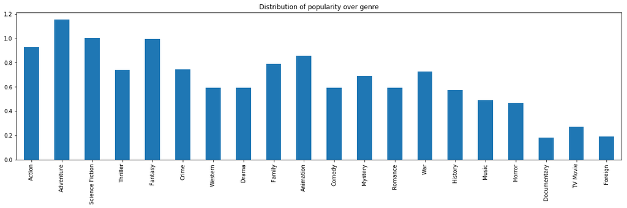

```python
# The distribution of popularity over each genre
distribution_over_genre('popularity')
```

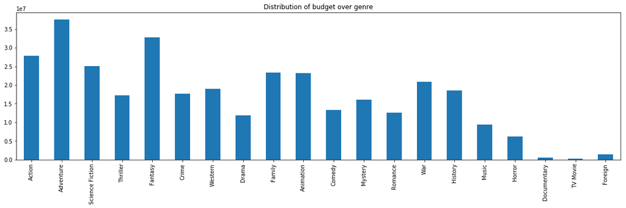

```python
# The distribution of budget over each genre
distribution_over_genre('budget')
```

Data indicates that Adventure, Fantasy, Action movies tend to have more budget than other genres.

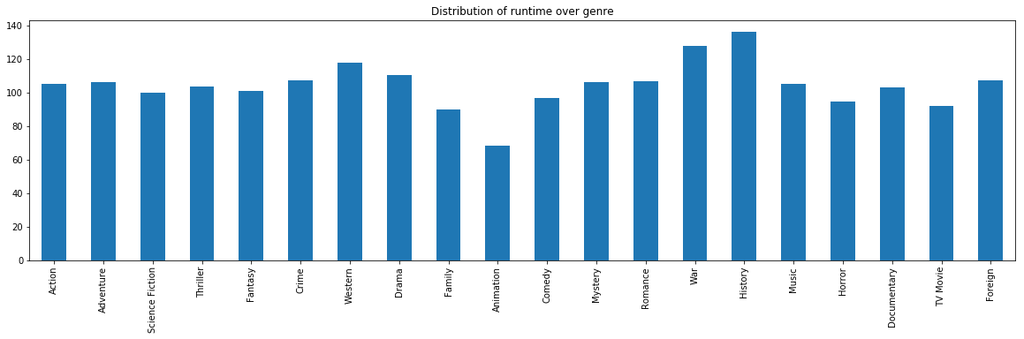

```python
# The distribution of runtime over each genre
distribution_over_genre('runtime')
```

The data indicates that the average runtime doesn't vary much across genres. However, History, War, Western genre movies seems to be longer than others and Animation seems to have shorter runtime on average.

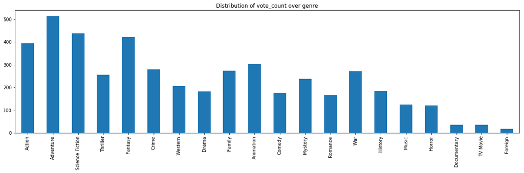

```python
# The distribution of vote count over each genre
distribution_over_genre('vote_count')
```

The data indicates that the following genres tend to the have the most votes - Adventure, Science Fiction, Fantasy, Action. This also suggests that people watches these genres more than the others. Foreign, Documentary and TV Movies are voted the least.

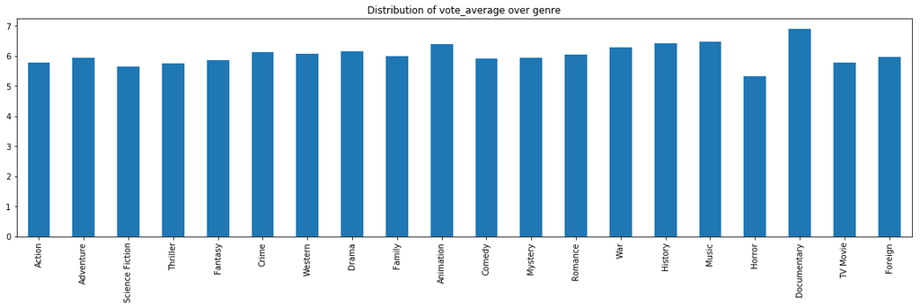

```python
# The distribution of vote average(rating) over each genre
distribution_over_genre('vote_average')
```

The average rating however, seems to not vary much over the genres. And quite counterintuitively, Documentary, Animation movies get good ratings on average.

Next I'll investigate the variation in popularity over the years for various genres.

```python
# Now, I'll analyse how the popularity of each genre varies over time
years = sorted(tmdb_df['release_year'].unique(), reverse=True)
popularity_genre_year = pd.DataFrame(index=genres, columns=years)
popularity_genre_year = popularity_genre_year.fillna(value=0)
popularity_genre_year.head()
```

|  | 2015 | 2014 | 2013 | 2012 | 2011 | 2010 | 2009 | 2008 | 2007 | 2006 | ... | 1969 | 1968 | 1967 | 1966 | 1965 | 1964 | 1963 | 1962 | 1961 | 1960 |
| --- | --- | --- | --- | --- | --- | --- | --- | --- | --- | --- | --- | --- | --- | --- | --- | --- | --- | --- | --- | --- | --- |
| Action | 0 | 0 | 0 | 0 | 0 | 0 | 0 | 0 | 0 | 0 | ... | 0 | 0 | 0 | 0 | 0 | 0 | 0 | 0 | 0 | 0 |
| Adventure | 0 | 0 | 0 | 0 | 0 | 0 | 0 | 0 | 0 | 0 | ... | 0 | 0 | 0 | 0 | 0 | 0 | 0 | 0 | 0 | 0 |
| Science Fiction | 0 | 0 | 0 | 0 | 0 | 0 | 0 | 0 | 0 | 0 | ... | 0 | 0 | 0 | 0 | 0 | 0 | 0 | 0 | 0 | 0 |
| Thriller | 0 | 0 | 0 | 0 | 0 | 0 | 0 | 0 | 0 | 0 | ... | 0 | 0 | 0 | 0 | 0 | 0 | 0 | 0 | 0 | 0 |
| Fantasy | 0 | 0 | 0 | 0 | 0 | 0 | 0 | 0 | 0 | 0 | ... | 0 | 0 | 0 | 0 | 0 | 0 | 0 | 0 | 0 | 0 |

5 rows × 56 columns

```python
# calculate average popularity of each genre on each year
for genre in genres:
    avg_popularity = tmdb_df.groupby([genre, 'release_year']).mean()['popularity'][1]
    popularity_genre_year.loc[genre] = avg_popularity

popularity_genre_year = popularity_genre_year.fillna(value=0)
popularity_genre_year
```

|  | 2015 | 2014 | 2013 | 2012 | 2011 | 2010 | 2009 | 2008 | 2007 | 2006 | ... | 1969 | 1968 | 1967 | 1966 | 1965 | 1964 | 1963 | 1962 | 1961 | 1960 |
| --- | --- | --- | --- | --- | --- | --- | --- | --- | --- | --- | --- | --- | --- | --- | --- | --- | --- | --- | --- | --- | --- |
| Action | 2.251415 | 1.682013 | 1.017374 | 1.131179 | 1.058096 | 0.935669 | 0.876691 | 0.894801 | 0.770140 | 0.753240 | ... | 0.539976 | 0.365562 | 0.723570 | 0.263347 | 0.451373 | 0.813087 | 0.951729 | 0.708945 | 0.365913 | 0.590724 |
| Adventure | 3.283786 | 2.430526 | 1.260832 | 1.461478 | 1.129488 | 1.360319 | 1.138422 | 1.008385 | 0.872411 | 0.942364 | ... | 0.748933 | 1.109147 | 1.025547 | 0.293593 | 0.581821 | 0.736431 | 0.728487 | 0.942513 | 0.767323 | 0.700981 |
| Science Fiction | 2.270751 | 2.294452 | 1.264518 | 0.938209 | 0.968919 | 0.827193 | 1.005731 | 0.773737 | 0.628712 | 0.794857 | ... | 0.172540 | 1.343642 | 0.187465 | 0.317790 | 0.101956 | 0.226636 | 0.467836 | 0.179212 | 0.274103 | 0.327905 |
| Thriller | 1.401877 | 1.041924 | 0.734572 | 0.676846 | 0.794807 | 0.741736 | 0.653917 | 0.678792 | 0.736963 | 0.666437 | ... | 0.871283 | 0.555919 | 0.701979 | 0.273869 | 0.343072 | 0.622580 | 0.719929 | 0.760582 | 0.000000 | 0.811910 |
| Fantasy | 1.740228 | 1.829351 | 1.019053 | 1.357831 | 1.011628 | 1.067366 | 1.048982 | 0.876319 | 0.985873 | 1.023134 | ... | 0.204098 | 0.445584 | 0.187009 | 0.424771 | 0.000000 | 0.599791 | 0.214071 | 0.235542 | 0.154073 | 0.428247 |
| Crime | 1.722032 | 0.883996 | 0.915736 | 0.863569 | 0.891704 | 0.693938 | 0.540392 | 0.769495 | 0.682438 | 0.669021 | ... | 0.948020 | 0.555919 | 0.538359 | 0.340702 | 0.387277 | 0.261690 | 0.552367 | 0.472816 | 0.806519 | 0.346480 |
| Western | 3.178796 | 0.673947 | 0.665255 | 1.732778 | 1.175800 | 0.724628 | 0.000000 | 0.365913 | 0.511944 | 0.463068 | ... | 0.509225 | 0.621202 | 0.189740 | 0.244657 | 0.191833 | 0.127679 | 0.246957 | 0.414180 | 0.210021 | 0.567759 |
| Drama | 0.937877 | 0.867474 | 0.660076 | 0.605073 | 0.598544 | 0.586280 | 0.566505 | 0.531565 | 0.560585 | 0.555578 | ... | 0.489887 | 0.377322 | 0.511467 | 0.339766 | 0.305288 | 0.364818 | 0.322448 | 0.392000 | 0.432233 | 0.566305 |
| Family | 1.369038 | 1.110831 | 0.823464 | 0.744235 | 0.776302 | 0.967878 | 0.822501 | 0.789651 | 0.873934 | 0.775500 | ... | 0.402277 | 0.426263 | 0.962015 | 0.398896 | 0.662713 | 0.878298 | 0.852632 | 0.323463 | 0.755722 | 0.278064 |
| Animation | 1.146298 | 1.124006 | 0.864769 | 0.805354 | 0.964938 | 0.694920 | 0.845430 | 0.860545 | 0.702605 | 0.798133 | ... | 0.292274 | 0.302135 | 1.348805 | 0.585717 | 0.600975 | 0.445746 | 2.180410 | 0.000000 | 2.631987 | 0.000000 |
| Comedy | 0.938527 | 0.866663 | 0.603933 | 0.595089 | 0.670374 | 0.586035 | 0.560836 | 0.513957 | 0.525933 | 0.627083 | ... | 0.270504 | 0.329548 | 0.434822 | 0.323658 | 0.358721 | 0.491229 | 0.444481 | 0.273183 | 0.679838 | 0.396000 |
| Mystery | 1.214847 | 1.013722 | 0.590179 | 0.495690 | 0.859816 | 1.109566 | 0.615212 | 0.613670 | 0.898185 | 0.781688 | ... | 0.567962 | 1.519456 | 0.401409 | 0.234951 | 0.209204 | 0.308091 | 0.421033 | 0.259220 | 0.712793 | 0.000000 |
| Romance | 0.948865 | 0.629171 | 0.610802 | 0.657424 | 0.675694 | 0.633717 | 0.614246 | 0.649842 | 0.527323 | 0.611784 | ... | 0.288267 | 0.260356 | 0.417445 | 0.351903 | 0.622780 | 0.221586 | 0.399573 | 0.365621 | 0.426036 | 0.541227 |
| War | 1.284511 | 1.481125 | 0.538608 | 0.676709 | 0.525725 | 0.648809 | 0.891897 | 0.631831 | 0.651834 | 0.546776 | ... | 0.316193 | 0.316055 | 0.485288 | 0.290459 | 0.312124 | 0.930959 | 0.664326 | 0.506162 | 0.531184 | 0.225863 |
| History | 1.007905 | 1.076321 | 0.788779 | 0.431110 | 0.309167 | 0.526931 | 0.509904 | 0.451229 | 0.546551 | 0.637088 | ... | 0.718985 | 0.481894 | 0.000000 | 0.335649 | 0.173948 | 0.316377 | 0.481618 | 0.600060 | 0.334463 | 0.412364 |
| Music | 0.635101 | 0.652112 | 0.360312 | 0.429719 | 0.398139 | 0.415393 | 0.506827 | 0.413559 | 0.713644 | 0.717687 | ... | 0.404251 | 0.515485 | 0.151540 | 0.000000 | 0.968850 | 0.753799 | 0.000000 | 0.323933 | 0.564749 | 0.423531 |
| Horror | 0.476670 | 0.483898 | 0.491909 | 0.434316 | 0.521678 | 0.419913 | 0.441957 | 0.322136 | 0.603356 | 0.401286 | ... | 0.141028 | 0.558403 | 0.289964 | 0.094397 | 0.124838 | 0.189650 | 0.376901 | 0.179368 | 0.254578 | 0.591450 |
| Documentary | 0.191955 | 0.151321 | 0.166475 | 0.154906 | 0.188776 | 0.225092 | 0.208910 | 0.170135 | 0.224261 | 0.206410 | ... | 0.000000 | 0.000000 | 0.095101 | 0.080598 | 0.000000 | 0.000000 | 0.000000 | 0.000000 | 0.000000 | 0.000000 |
| TV Movie | 0.260574 | 0.296038 | 0.267746 | 0.205179 | 0.411282 | 0.355794 | 0.304913 | 0.252519 | 0.153647 | 0.373354 | ... | 0.528660 | 0.000000 | 0.000000 | 0.000000 | 0.600975 | 0.000000 | 0.000000 | 0.000000 | 0.000000 | 0.000000 |
| Foreign | 0.000000 | 0.000000 | 0.000000 | 0.099589 | 0.129987 | 0.197701 | 0.221696 | 0.210030 | 0.227935 | 0.237193 | ... | 0.000000 | 0.000000 | 0.000000 | 0.361556 | 0.004770 | 0.152209 | 0.351647 | 0.235542 | 0.113651 | 0.194948 |

20 rows × 56 columns

Created a new dataframe to contain average popularity of each genre over the years. Next I'll use various plot to understand the trends.

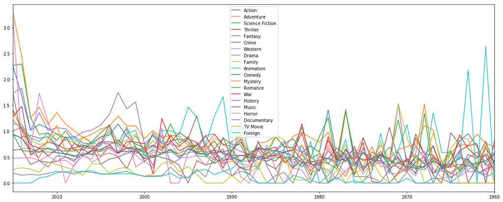

```python
# plot the distribution of average popularity of each genre over the years
popularity_genre_year.transpose().plot(figsize=(20, 8))
plt.show()
```

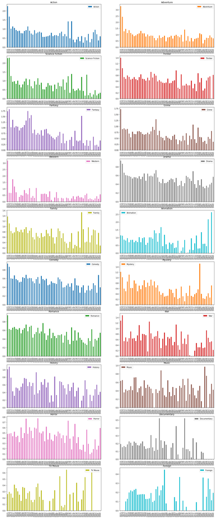

```python
# distribution of popularity of each genre over the years
fig, axes = plt.subplots(nrows=10, ncols=2, figsize=(20, 50))
popularity_genre_year.transpose().plot(kind='bar', ax = axes, subplots=True)
plt.show()
```

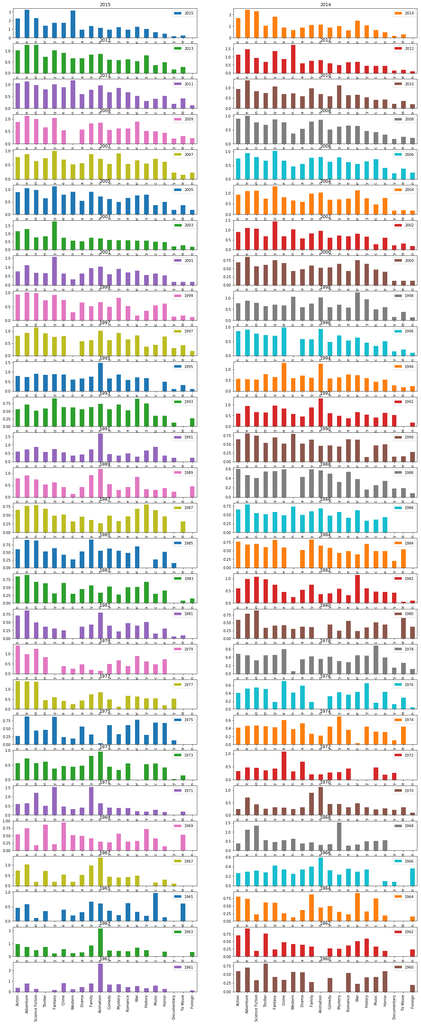

```python
# distribution of popularity of each genre on a given year
fig, axes = plt.subplots(nrows=28, ncols=2, figsize=(20, 50))
popularity_genre_year.plot(kind='bar', ax = axes, subplots=True)
plt.show()
```

I found the below trends in the data -

Action: Mostly favorite all the time. Less popular during 1965 - 1975. Popularity spiked during recent years and late 70s

Adventure: Mostly favourite. Less popular during early 70s. Popularity increased in recent years

Science Fiction: More popular in recent times and late 70s. Less popular during early and mid 60s

Thriller: Very popular all the time. Popularity decreased in late 70s

Crime: Popularity increased after 90s

Drama: All time favorite. Popularity never ceases.

Family: Mostly favorite all the time. Less popularity in late 80s

Animation: Saw the worst time in the 70s

Comedy: All time favourite

Mystry: Not much popular 70s and 80s

Romance: All time favourite

War movies: Less poopular during late 60s and early 70s

History ans music: Show similar trends and with averge popularity

### Investigate properties of high revenue

Now, I'll investigate how the revenue varies with other parameters. First, I'll investigate how average revenue varies acroos genre.

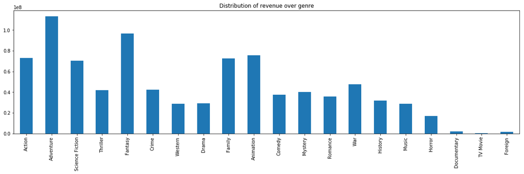

```python
# The distribution of popularity over each genre
distribution_over_genre('revenue')
```

The plot indicates that Adventure, Fantasy, Animation, Science Fiction, Family and Action movies tend to genrate higher revenue compared to others.

```python
years = sorted(tmdb_df['release_year'].unique(), reverse=True)

# utility function plot distribution of data over years
def distribution_var_years(var):
    '''
    This function takes a variable as input and plots the distribution
    of that variable over years
    '''
    distribution_years = pd.Series(index=years)
    for year in years:
        distribution_years[year] = tmdb_df.groupby('release_year').mean()[var][year]
    title = 'Distribution of ' + var + ' over years'
    distribution_years.plot(kind='bar', figsize=(20, 5), title = title)
    plt.show()
```

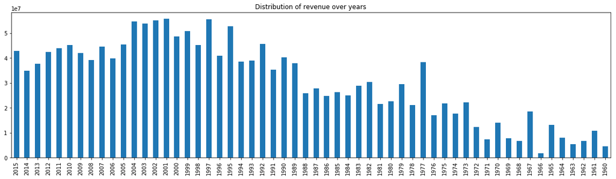

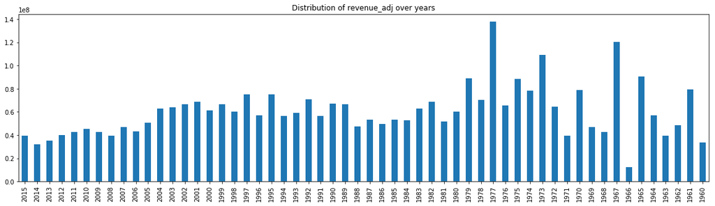

```python
# plot distribution of revenue over years
distribution_var_years('revenue')

# plot distribution of revenue_adj over years
distribution_var_years('revenue_adj')
```

```python
# utility function to create scatter plot of var1 and var2
def plot_scatter(x_var, y_var):
    fig = plt.figure(figsize=(10,4))
    plt.scatter(np.array(tmdb_df[x_var]), np.array(tmdb_df[y_var]))
    plt.title('Scatter plot of ' + x_var + ' vs ' + y_var)
    plt.xlabel(x_var)
    plt.ylabel(y_var)
    plt.show()
```

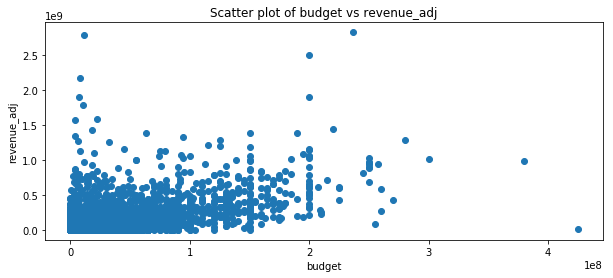

```python
# plot budget vs renenue
plot_scatter('budget', 'revenue_adj')
```

There is also a genral positive linear trend in the data suggesting that movies with more budget tends to generate more revenue.

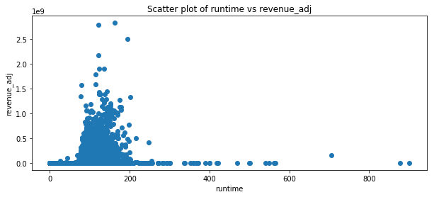

```python
#plot runtime vs revenue
plot_scatter('runtime', 'revenue_adj')
```

The above plot is more of a general trend of the runtime. The runtime of 100mins tends to generate more revenue.

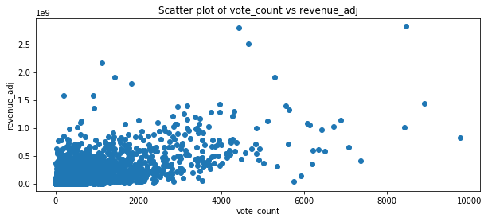

```python
#plot vote count vs revenue
plot_scatter('vote_count', 'revenue_adj')
```

This suggests a more or less positive linear relation between vote-count and revenue. Higher vote count suggests that more people watch the movies which can explain higher revenue.

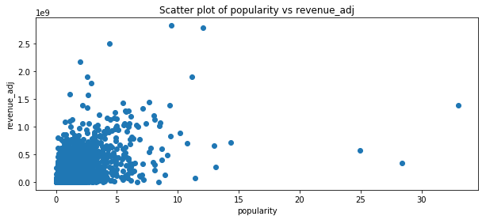

```python
#plot popularity vs revenue
plot_scatter('popularity', 'revenue_adj')
```

The data suggests kind of a positive effect of popularity on revenue.

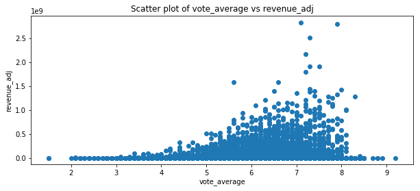

```python
#plot vote_average vs revenue
plot_scatter('vote_average', 'revenue_adj')
```

This suggests that the movies with average vote between 6 and 8 tends to generate more revenue. Quite counter-intuitively movies with high ratings like 9 tends to generate very low revenue. This tends to indicate that many cinematically briliant movies may not be that hit on the box office.

While the above curves suggest a bit of trends in the data, it is not very clear. I'll so some corellation analysis next in the hope of finding somethign useful. I'll use the average revenue over the years and try to corelate that with average populariity, vote-count, vote-average.

```python
years_df = tmdb_df.groupby('release_year').mean()
years_df.head()
```

| release_year | id | popularity | budget | revenue | runtime | vote_count | vote_average | budget_adj | revenue_adj | Action | ... | Comedy | Mystery | Romance | War | History | Music | Horror | Documentary | TV Movie | Foreign |
| --- | --- | --- | --- | --- | --- | --- | --- | --- | --- | --- | --- | --- | --- | --- | --- | --- | --- | --- | --- | --- | --- |
| 1960 | 15715.281250 | 0.458932 | 6.892796e+05 | 4.531406e+06 | 110.656250 | 77.531250 | 6.325000 | 5.082036e+06 | 3.340991e+07 | 0.250000 | ... | 0.250000 | 0.000000 | 0.187500 | 0.062500 | 0.156250 | 0.031250 | 0.218750 | 0.0 | 0.0 | 0.031250 |
| 1961 | 18657.000000 | 0.422827 | 1.488290e+06 | 1.089420e+07 | 119.419355 | 77.580645 | 6.374194 | 1.085687e+07 | 7.947167e+07 | 0.225806 | ... | 0.322581 | 0.032258 | 0.225806 | 0.064516 | 0.096774 | 0.064516 | 0.096774 | 0.0 | 0.0 | 0.032258 |
| 1962 | 17001.062500 | 0.454783 | 1.710066e+06 | 6.736870e+06 | 124.343750 | 74.750000 | 6.343750 | 1.232693e+07 | 4.856238e+07 | 0.250000 | ... | 0.156250 | 0.125000 | 0.156250 | 0.093750 | 0.125000 | 0.031250 | 0.156250 | 0.0 | 0.0 | 0.031250 |
| 1963 | 16556.000000 | 0.502706 | 2.156809e+06 | 5.511911e+06 | 111.323529 | 82.823529 | 6.329412 | 1.535687e+07 | 3.924580e+07 | 0.117647 | ... | 0.382353 | 0.176471 | 0.235294 | 0.029412 | 0.117647 | 0.000000 | 0.264706 | 0.0 | 0.0 | 0.058824 |
| 1964 | 17379.571429 | 0.412428 | 9.400753e+05 | 8.118614e+06 | 109.214286 | 74.690476 | 6.211905 | 6.608980e+06 | 5.707603e+07 | 0.119048 | ... | 0.380952 | 0.095238 | 0.214286 | 0.071429 | 0.071429 | 0.119048 | 0.142857 | 0.0 | 0.0 | 0.023810 |

5 rows × 29 columns

```python
# descriptive statistics of revenue
years_df['revenue_adj'].describe()
```

```
count    5.600000e+01
mean     6.043660e+07
std      2.165163e+07
min      1.237527e+07
25%      4.637996e+07
50%      5.802844e+07
75%      6.853892e+07
max      1.376362e+08
Name: revenue_adj, dtype: float64
```

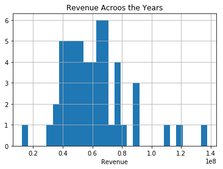

```python
# Distribution of revenue over the years
years_df['revenue_adj'].hist(bins=30)
plt.xlabel('Revenue')
plt.title('Revenue Acroos the Years');
plt.show()
```

The data suggests that the average revenue falls between 40M and 80M across the years with the average being around 60M.

```python
# Investigate correlations
years_df[['popularity', 'vote_count', 'vote_average', 'budget', 'revenue']].corr()
```

|  | popularity | vote_count | vote_average | budget | revenue |
| --- | --- | --- | --- | --- | --- |
| popularity | 1.000000 | 0.849407 | -0.580536 | 0.668540 | 0.759524 |
| vote_count | 0.849407 | 1.000000 | -0.661674 | 0.781743 | 0.809127 |
| vote_average | -0.580536 | -0.661674 | 1.000000 | -0.728689 | -0.704660 |
| budget | 0.668540 | 0.781743 | -0.728689 | 1.000000 | 0.906209 |
| revenue | 0.759524 | 0.809127 | -0.704660 | 0.906209 | 1.000000 |

This correlation coefficients suggests that revenue strongly positively correlated with popularity, vote_count and budget which is out common intuition. However, revenue is strongly negatively correlated with vote-average or rating. This suggests the same insight as earlier that cinematically briliant movies tend to generate less revenue. In the next three plots we'll investigate this same trend graphically.

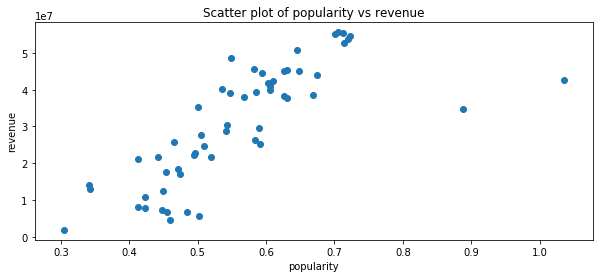

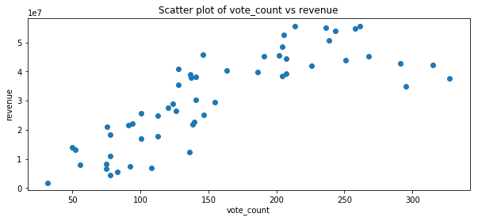

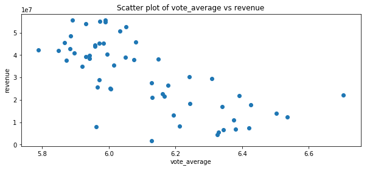

```python
# utility function to create scatter plot of var1 and var2
def plot_scatter_years(x_var, y_var):
    fig = plt.figure(figsize=(10,4))
    plt.scatter(np.array(years_df[x_var]), np.array(years_df[y_var]))
    plt.title('Scatter plot of ' + x_var + ' vs ' + y_var)
    plt.xlabel(x_var)
    plt.ylabel(y_var)
    plt.show()

plot_scatter_years('popularity', 'revenue')
plot_scatter_years('vote_count', 'revenue')
plot_scatter_years('vote_average', 'revenue')
```

### Investigate runtime over the years

I'll create some descriptive statistics and a plot to investigate average runtime across the years.

```python
# get statistics for average runtime
years_df['runtime'].describe()
```

```
count     56.000000
mean     105.794894
std        5.523432
min       96.329771
25%      101.910776
50%      106.016671
75%      107.746542
max      124.343750
Name: runtime, dtype: float64
```

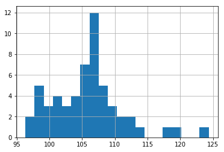

```python
# get histogram for average runtime
years_df['runtime'].hist(bins=20)
plt.show()
```

### Investigate ratings over the years

Lastly, I'll get some descriptive statistics and a plot for vote_average over the years

```python
# get statistics for average rating
years_df['vote_average'].describe()
```

```
count    56.000000
mean      6.105982
std       0.204557
min       5.788336
25%       5.958838
50%       6.041295
75%       6.242106
max       6.703636
Name: vote_average, dtype: float64
```

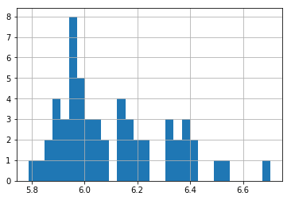

```python
# plot histogram of average rating
years_df['vote_average'].hist(bins=30)
plt.show()
```

Data suggests that most ratings lies between 5 to 7 with the average being at 6

## Limitations and Further Scope

1. This study doesn't check how the various mesaures are computed like popularity, vote_count, vote_average. They are considered same as their face value intuitively suggegsting that higher the measures are the higher is the value of that metric.
2. Revenue models also are not researched. Like revenue can be measures in terms of ticket sales, broadcase profits etc. But those are not researched in details.
3. Whenever the study suggests a trend, it is due to the observational statistics. No statistical test has been done to infer anything. Also, whenever a possible cause is cited, it is cited in an informal manner and should be considered as an educated guess.
4. No statement imply causation. For causation, we need to perform experiments which is not done here.
5. There were a lot of data in this dataset which are not used in the analysis like cast, keywords, director etc. I strongly think that very useful informartion can be found if those properties are investigated in detail.

## Conclusions

This completes the exploration of the dataset. I did all the relevant discussion at the end of each analysis step, so not repeating it again. I found useful information and trends in the data which can be used to predict the popularity or may be the revenue of future movies before they are even released.